# mnist

- B has close but higher test accuracy than C
- C has better performance in validation set
- C does not overfit

continue adding parameters, here we choose a larger filter (filter=32)

```python
twocnnD = tf.keras.models.Sequential([

        tf.keras.layers.Input((28,28,1)),
        tf.keras.layers.Conv2D(filters=32, kernel_size=(5,5), padding='same', kernel_regularizer=l2(1e-5)),
        tf.keras.layers.BatchNormalization(),
        tf.keras.layers.Activation('relu'),
        tf.keras.layers.MaxPool2D(pool_size=(2,2)),
        tf.keras.layers.Dropout(0.5),

        tf.keras.layers.Conv2D(filters=32, kernel_size=(5,5), padding='same', kernel_regularizer=l2(1e-5)),
        tf.keras.layers.BatchNormalization(),
        tf.keras.layers.Activation('relu'),
        tf.keras.layers.MaxPool2D(pool_size=(2,2)),
        tf.keras.layers.Dropout(0.5),

        tf.keras.layers.Flatten(),
        tf.keras.layers.Dense(256, 'relu'),
        tf.keras.layers.Dropout(0.5),
        tf.keras.layers.Dense(10, 'softmax')

])

twocnnD.compile(optimizer=tf.keras.optimizers.Adam(learning_rate=0.001),
                loss='sparse_categorical_crossentropy',
                metrics=['accuracy'])

history_twocnnD = twocnnD.fit(x_train, y_train, batch_size=128, epochs=100,
                                validation_split=0.2)
```

```python
twocnnD.summary()
```

```
Model: "sequential_40"
_________________________________________________________________
Layer (type)                 Output Shape              Param #
=================================================================
conv2d_43 (Conv2D)           (None, 28, 28, 32)        832
_________________________________________________________________
batch_normalization_25 (Batc (None, 28, 28, 32)        128
_________________________________________________________________
activation_25 (Activation)   (None, 28, 28, 32)        0
_________________________________________________________________
max_pooling2d_32 (MaxPooling (None, 14, 14, 32)        0
_________________________________________________________________
dropout_59 (Dropout)         (None, 14, 14, 32)        0
_________________________________________________________________
conv2d_44 (Conv2D)           (None, 14, 14, 32)        25632
_________________________________________________________________
batch_normalization_26 (Batc (None, 14, 14, 32)        128
_________________________________________________________________
activation_26 (Activation)   (None, 14, 14, 32)        0
_________________________________________________________________
max_pooling2d_33 (MaxPooling (None, 7, 7, 32)          0
_________________________________________________________________
dropout_60 (Dropout)         (None, 7, 7, 32)          0
_________________________________________________________________
flatten_40 (Flatten)         (None, 1568)              0
_________________________________________________________________
dense_80 (Dense)             (None, 256)               401664
_________________________________________________________________
dropout_61 (Dropout)         (None, 256)               0
_________________________________________________________________
dense_81 (Dense)             (None, 10)                2570
=================================================================
Total params: 430,954
Trainable params: 430,826
Non-trainable params: 128
_________________________________________________________________
```

```python
twocnnD.evaluate(x_test, y_test, verbose=2)
```

```
313/313 - 1s - loss: 0.0222 - accuracy: 0.9953
```

```
[0.022216523066163063, 0.9952999949455261]
```

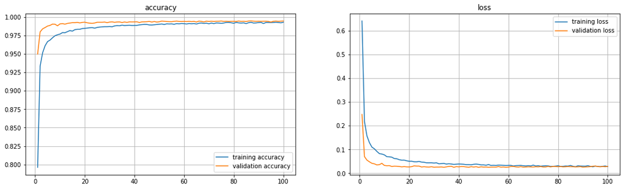

```python
plt.figure(figsize=(18,5))
epoch = [i for i in range(1,101)]
plt.subplot(1,2,1)
plt.plot(epoch, history_twocnnD.history['accuracy'], label='training accuracy')
plt.plot(epoch, history_twocnnD.history['val_accuracy'], label='validation accuracy')
plt.title('accuracy')
plt.legend()
plt.grid()

plt.subplot(1,2,2)
plt.plot(epoch, history_twocnnD.history['loss'], label='training loss')
plt.plot(epoch, history_twocnnD.history['val_loss'], label='validation loss')
plt.title('loss')
plt.grid()
plt.legend()
plt.show()
```

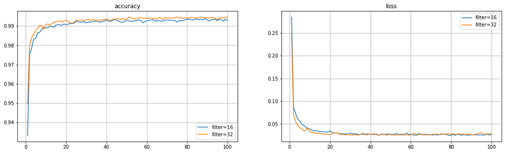

```python
# compare two layer cnn with different filters
plt.figure(figsize=(18,5))
epoch = [i for i in range(1,101)]
plt.subplot(1,2,1)
plt.plot(epoch, history_twocnnC.history['val_accuracy'], label='filter=16')
plt.plot(epoch, history_twocnnD.history['val_accuracy'], label='filter=32')
plt.title('accuracy')
plt.legend()
plt.grid()

plt.subplot(1,2,2)
plt.plot(epoch, history_twocnnC.history['val_loss'], label='filter=16')
plt.plot(epoch, history_twocnnD.history['val_loss'], label='filter=32')
plt.title('loss')
plt.grid()
plt.legend()
plt.show()
```

the loss are quite close here, and filter=32 is almost a string line.

since filter=32 has higher accuracy, we think it is our best model.

try data augmentation

```python
# try three data augmentation methods
# 1. filp up and down
# 2. filp right and left
# 3. adjust contrast of images

def dataAug1(image):
  image_output = tf.image.random_flip_up_down(image, seed=0)
  return image_output

def dataAug2(image):
  image_output = tf.image.random_flip_left_right(image, seed=0)
  return image_output

def dataAug3(image):
  image_output = tf.image.adjust_contrast(image, 1.5)
  return image_output

aug_data = np.zeros([60000,28,28,1])
for i in range(60000):
  if i<20000:
    aug_data[i] = dataAug1(x_train[i])
  elif 20000<=i<40000:
    aug_data[i] = dataAug2(x_train[i])
  else:
    aug_data[i] = dataAug3(x_train[i])

train_aug = np.concatenate((x_train, aug_data))
label_aug = np.concatenate((y_train, y_train))

train_aug.shape, label_aug.shape
```

```
((120000, 28, 28, 1), (120000,))
```

```python
aug = tf.keras.models.Sequential([

        tf.keras.layers.Input((28,28,1)),
        tf.keras.layers.Conv2D(filters=32, kernel_size=(5,5), padding='same', kernel_regularizer=l2(1e-5)),
        tf.keras.layers.BatchNormalization(),
        tf.keras.layers.Activation('relu'),
        tf.keras.layers.MaxPool2D(pool_size=(2,2)),
        tf.keras.layers.Dropout(0.5),

        tf.keras.layers.Conv2D(filters=32, kernel_size=(5,5), padding='same', kernel_regularizer=l2(1e-5)),
        tf.keras.layers.BatchNormalization(),
        tf.keras.layers.Activation('relu'),
        tf.keras.layers.MaxPool2D(pool_size=(2,2)),
        tf.keras.layers.Dropout(0.5),

        tf.keras.layers.Flatten(),
        tf.keras.layers.Dense(256, 'relu'),
        tf.keras.layers.Dropout(0.5),
        tf.keras.layers.Dense(10, 'softmax')

])

aug.compile(optimizer=tf.keras.optimizers.Adam(learning_rate=0.001),
                loss='sparse_categorical_crossentropy',
                metrics=['accuracy'])

history_aug = aug.fit(train_aug, label_aug, batch_size=128, epochs=100,
                                validation_split=0.2)
```

```python
aug.summary()
```

```
Model: "sequential_41"
_________________________________________________________________
Layer (type)                 Output Shape              Param #
=================================================================
conv2d_45 (Conv2D)           (None, 28, 28, 32)        832
_________________________________________________________________
batch_normalization_27 (Batc (None, 28, 28, 32)        128
_________________________________________________________________
activation_27 (Activation)   (None, 28, 28, 32)        0
_________________________________________________________________
max_pooling2d_34 (MaxPooling (None, 14, 14, 32)        0
_________________________________________________________________
dropout_62 (Dropout)         (None, 14, 14, 32)        0
_________________________________________________________________
conv2d_46 (Conv2D)           (None, 14, 14, 32)        25632
_________________________________________________________________
batch_normalization_28 (Batc (None, 14, 14, 32)        128
_________________________________________________________________
activation_28 (Activation)   (None, 14, 14, 32)        0
_________________________________________________________________
max_pooling2d_35 (MaxPooling (None, 7, 7, 32)          0
_________________________________________________________________
dropout_63 (Dropout)         (None, 7, 7, 32)          0
_________________________________________________________________
flatten_41 (Flatten)         (None, 1568)              0
_________________________________________________________________
dense_82 (Dense)             (None, 256)               401664
_________________________________________________________________
dropout_64 (Dropout)         (None, 256)               0
_________________________________________________________________
dense_83 (Dense)             (None, 10)                2570
=================================================================
Total params: 430,954
Trainable params: 430,826
Non-trainable params: 128
_________________________________________________________________
```

```python
aug.evaluate(x_test, y_test, verbose=2)
```

```
313/313 - 1s - loss: 0.0328 - accuracy: 0.9931
```

```
[0.03277586027979851, 0.9930999875068665]
```

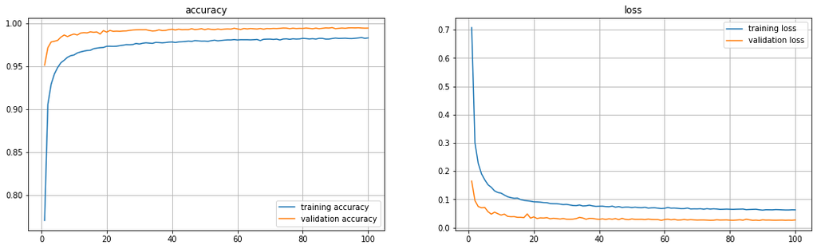

```python
plt.figure(figsize=(18,5))
epoch = [i for i in range(1,101)]
plt.subplot(1,2,1)
plt.plot(epoch, history_aug.history['accuracy'], label='training accuracy')
plt.plot(epoch, history_aug.history['val_accuracy'], label='validation accuracy')
plt.title('accuracy')
plt.legend()
plt.grid()

plt.subplot(1,2,2)
plt.plot(epoch, history_aug.history['loss'], label='training loss')
plt.plot(epoch, history_aug.history['val_loss'], label='validation loss')
plt.title('loss')
plt.grid()
plt.legend()
plt.show()
```

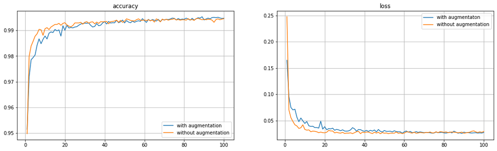

```python
# compare whether or not use data augmentation
plt.figure(figsize=(18,5))
epoch = [i for i in range(1,101)]
plt.subplot(1,2,1)
plt.plot(epoch, history_aug.history['val_accuracy'], label='with augmentation')
plt.plot(epoch, history_twocnnD.history['val_accuracy'], label='without augmentation')
plt.title('accuracy')
plt.legend()
plt.grid()

plt.subplot(1,2,2)
plt.plot(epoch, history_aug.history['val_loss'], label='with augmentaton')
plt.plot(epoch, history_twocnnD.history['val_loss'], label='without augmentation')
plt.title('loss')
plt.grid()
plt.legend()
plt.show()
```

without augmentation has better performance??

END